# Er det høyde som bestemmer inntekt?

Assignment 2 i MSB105 Data Science

Kevin Ha - 571821

Ola Andre Olofsson - 170745

## Innledning

Dette er oppgave 2 i kurset MSB105 Data Science. I den følgende artikkelen anvendes datasettet **heights** fra pakken **modelr** for å besvare følgende problemstilling; **Er det høyde som bestemmer inntekt?**

## En kort litteraturgjennomgang

Judge and Cable (2004) hevder at “høyde påvirker inntekt.” Dette kan ved første øyekast synes som en gammel myte, men kanskje er det mer i det enn man først skulle tro. For å støtte dette utsagnet referer de til Roberts and Herman (1986) som viser til at høyde er et trekk som er ettertraktet i en sosial sammenheng.

Denne forskningen mener i tillegg at høyere mennesker er mer overbevisende. De viser til Higham and Carment (1992) som påstår at høyere mennesker har høyere sannsynlighet til å få lederstillinger. Judge and Cable (2004) teoriserer at dette muligens har røtter i biologi, ettersom høyde i naturen er et mål på styrke.

Burns (1993) viste at 78% av ansettelser innen salg, var mennesker med over gjennomsnittlig høyde. Rekruttererne argumenterte med at høydeforskjellen skyldtes at høyere selgere gjør seg mer bemerket enn lavere selgere.

Judge and Cable (2004) ville undersøke dette ved å utføre en studie med tre hovedpunkter. Først å fremstille en modell som viser forholdet mellom høyde og karrieresuksess. Dette var ikke utført tidligere. Steg to var å utføre en metaanalyse på tidligere analyser og litteratur for å se etter generelle implikasjoner. Siste steget var å utføre fire nye undersøkelser på forholdet mellom en persons høyde og inntekt.

Argumentet for å se på sammenhengen mellom en persons høyde og inntekt var at de anså inntekt for å være den primære indikatoren for karrieresuksess. Men i følge Judge et al. (1995) og Whitely, Dougherty, and Dreher (1991), så er det nesten ingen støttende forskning på dette.

Judge and Cable (2004) tar utgangspunkt i flere menneskelige faktorer for å utvikle en modell for forholdet mellom en persons høyde og inntekt.

Noen av faktorene de så på var selvtillit og sosial rang. Judge and Cable (2004) mente dette var to viktige punkter i analysen fordi disse to faktorene påvirker ens arbeidsinnsats, samt hvordan en blir behandlet i arbeidslivet av arbeidsgiver. De mente faktorene ville påvirke en persons suksess i arbeidslivet, og innebære at en høyere person ville ha høyere inntekt enn en lavere person.

Judge and Cable (2004) kom frem til at det var en rekke effekter av en persons høyde i arbeidslivet. Økt høyde kan medføre bedre selvtillit, og følgelig høyere sosial rang, som igjen vil resultere i bedre arbeidsinnsats og muligheter - og eventuelt suksess.

For å støtte opp under grunnlaget for modellen, henviste de til flere tidligere studier gjort rundt høyde, karrièremuligheter og suksess, samt til flere andre studier om hvordan selvtillit blir påvirket av ulike personlige faktorer.

Judge and Cable (2004) konkluderte med at det var en direkte empirisk sammenheng mellom en persons høyde og inntekt.

## Analyse med egen versjon av datasettet

I henhold til oppgaveteksten, kaller vi datasettet for *hoyde*.

```r
# Vi selekterer ut dataene for heights fra pakken modelr, og angir deretter benevnelsen "hoyde"

# Gir to dataframe heights og hoyde
#data('heights', package = 'modelr')
#hoyde <- heights
# Alternativet under gir oss bare hoyde
hoyde <- modelr::heights

# Vi rydder videre opp i benevnelsene ved å slik at de blir enklere å jobbe med. Vi oversetter dem til norsk, samt omgjør måleenhetene til metriske.

hoyde$inntekt <- hoyde$income*8.5
hoyde$height_cm <- hoyde$height*2.54
kable(summary(hoyde[,9:10]))
```

|  | inntekt | height_cm |
| --- | --- | --- |
|  | Min. : 0 | Min. :132.1 |
|  | 1st Qu.: 1407 | 1st Qu.:162.6 |
|  | Median : 251511 | Median :170.2 |
|  | Mean : 350234 | Mean :170.4 |
|  | 3rd Qu.: 467500 | 3rd Qu.:177.8 |
|  | Max. :2922555 | Max. :213.4 |

```r
# Over er helt ok, men jeg vil anbefale heller å bruke tidyverse og mutate
# hoyde <- hoyde %>%
#  mutate(
#    inntekt = income * 8.5,
#    height_cm = height * 2.54,
#  )
# Til slutt kan vi oppsummere de interessante variablene i metrisk form, samt oversatt.
```

### Beskrivende statistikk (beskrivelse av data)

Datasettet vi bruker er fra R (R Core Team 2021) pakken, *modelr* (Wickham 2020) og er hentet fra National Longitudinal Study, som er sponset av U.S. Bureau of Labor Statistics. Dataene stammer fra 2012. Følgende er forklaringer av variablene:

- *height* = høyde i tommer
- *weight* = vekt i pund
- *age* = alder mellom 47 og 56
- *marital* = sivilstatus
- *sex* = kjønn
- *education* = år med utdanning
- *afqt* = prosentskår på test for militær egnethet

### Exploratory Data Analysis (EDA) vha. ggplot

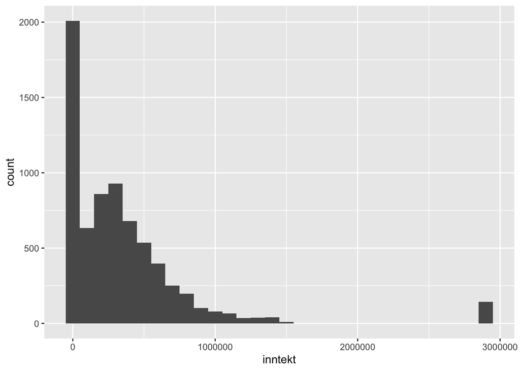

```r
# Her har vi laget et histogram av variablene income (også kalt inntekt)
ggplot(data = hoyde,
       aes(x = inntekt)) +
  geom_histogram(binwidth = 100000)
```

Her ser vi noen utliggere på høyresiden. Dette er 143 observasjoner av personer som tjener rett under 3MNOK. De skiller seg fra resten av observasjonene i histogrammet grunnet at både median- og snittlønn er langt lavere.

Vi har også personer *uten* inntekt i datasettet.

Til slutt ta en titt på forklaringsvariablene, f.eks utdanning, evnenivå. Først med hele datasettet.

```r
 summary(hoyde)
```

```
##      income             height         weight           age
##  Min.   :     0.0   Min.   :52.0   Min.   : 76.0   Min.   :47.00
##  1st Qu.:   165.5   1st Qu.:64.0   1st Qu.:157.0   1st Qu.:49.00
##  Median : 29589.5   Median :67.0   Median :184.0   Median :51.00
##  Mean   : 41203.9   Mean   :67.1   Mean   :188.3   Mean   :51.33
##  3rd Qu.: 55000.0   3rd Qu.:70.0   3rd Qu.:212.0   3rd Qu.:53.00
##  Max.   :343830.0   Max.   :84.0   Max.   :524.0   Max.   :56.00
##                                    NA's   :95
##       marital         sex         education          afqt
##  single   :1124   male  :3402   Min.   : 1.00   Min.   :  0.00
##  married  :3806   female:3604   1st Qu.:12.00   1st Qu.: 15.12
##  separated: 366                 Median :12.00   Median : 36.76
##  divorced :1549                 Mean   :13.22   Mean   : 41.21
##  widowed  : 161                 3rd Qu.:15.00   3rd Qu.: 65.24
##                                 Max.   :20.00   Max.   :100.00
##                                 NA's   :10      NA's   :262
##     inntekt          height_cm
##  Min.   :      0   Min.   :132.1
##  1st Qu.:   1407   1st Qu.:162.6
##  Median : 251511   Median :170.2
##  Mean   : 350234   Mean   :170.4
##  3rd Qu.: 467500   3rd Qu.:177.8
##  Max.   :2922555   Max.   :213.4
##
```

EDA er vel knapp. Se mitt løsningsforslag for andre ting som kunne vært gjort

### Regresjonsanalyser

```r
(lm(inntekt ~ height_cm, data = hoyde)) %>%
  summary()
```

```
##
## Call:
## lm(formula = inntekt ~ height_cm, data = hoyde)
##
## Residuals:
##     Min      1Q  Median      3Q     Max
## -778460 -267842  -92589  126498 2727038
##
## Coefficients:
##               Estimate Std. Error t value            Pr(>|t|)
## (Intercept) -1350548.5    91236.9  -14.80 <0.0000000000000002 ***
## height_cm       9978.5      534.3   18.68 <0.0000000000000002 ***
## ---
## Signif. codes:  0 '***' 0.001 '**' 0.01 '*' 0.05 '.' 0.1 ' ' 1
##
## Residual standard error: 463700 on 7004 degrees of freedom
## Multiple R-squared:  0.04744,    Adjusted R-squared:  0.0473
## F-statistic: 348.8 on 1 and 7004 DF,  p-value: < 0.00000000000000022
```

Analysen ovenfor er helt grei, men jeg vil likevel foreslå følgende arbeidsmåte.

```r
# Definer modellen
mod0 <- 'inntekt ~ height_cm'
```

Regresjonsmodellen

```r
lm0 <- hoyde %>%
  # her kan eventuelle filter() eller mutate() kommandoer legges inn
  # data = . nødvendig siden lm() er en av de få kommandoene som ikke
  # har data/input som første argument
  lm(mod0, data = .)
```

```r
summary(lm0)
```

```
##
## Call:
## lm(formula = mod0, data = .)
##
## Residuals:
##     Min      1Q  Median      3Q     Max
## -778460 -267842  -92589  126498 2727038
##
## Coefficients:
##               Estimate Std. Error t value            Pr(>|t|)
## (Intercept) -1350548.5    91236.9  -14.80 <0.0000000000000002 ***
## height_cm       9978.5      534.3   18.68 <0.0000000000000002 ***
## ---
## Signif. codes:  0 '***' 0.001 '**' 0.01 '*' 0.05 '.' 0.1 ' ' 1
##
## Residual standard error: 463700 on 7004 degrees of freedom
## Multiple R-squared:  0.04744,    Adjusted R-squared:  0.0473
## F-statistic: 348.8 on 1 and 7004 DF,  p-value: < 0.00000000000000022
```

Her ser vi at en økning i høyden på 1 cm, gir 9978.5 kr mer i årlig inntekt. La oss prøve med datasett uten de 2% med toppinntekt, og uten de med inntekt = 0.

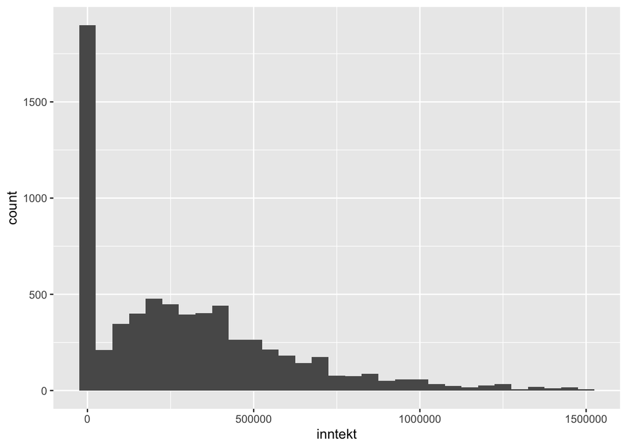

```r
# Nå filtrerer vi ut de observasjonene med inntekt lavere enn 1,6MNOK. Vi ser da under "Environment" at vi sitter igjen med 6863 observasjoner i datasettet "hoyde_max_inntekt".
hoyde_max_inntekt <- hoyde %>%
  filter(inntekt < 1600000)
# HVORFOR IKKE BARE SLÅ SAMMEN PIPE-EN?
hoyde %>%
  filter(inntekt < 1600000) %>%
# For illustrajonshensikter, kan vi også se hvordan dette histogrammet har endret seg i forhold til det forrige.
  ggplot(mapping = aes(x = inntekt)) +
  geom_histogram(binwidth = 50000)
```

Her ser vi at utliggerne forsvinner, ettersom den vannrette aksen kun viser observasjoner hvor inntekt er lavere enn 1.600.000.

```r
(lm(inntekt ~ height_cm, data = hoyde_max_inntekt)) %>%
  summary()
```

```
##
## Call:
## lm(formula = inntekt ~ height_cm, data = hoyde_max_inntekt)
##
## Residuals:
##     Min      1Q  Median      3Q     Max
## -547811 -236923  -54031  158327 1265382
##
## Coefficients:
##              Estimate Std. Error t value            Pr(>|t|)
## (Intercept) -695742.7    58424.7  -11.91 <0.0000000000000002 ***
## height_cm      5828.4      342.5   17.02 <0.0000000000000002 ***
## ---
## Signif. codes:  0 '***' 0.001 '**' 0.01 '*' 0.05 '.' 0.1 ' ' 1
##
## Residual standard error: 293300 on 6861 degrees of freedom
## Multiple R-squared:  0.0405, Adjusted R-squared:  0.04036
## F-statistic: 289.6 on 1 and 6861 DF,  p-value: < 0.00000000000000022
```

Her ser vi at en økning i høyden på 1 cm, gir 5828.4 kr mer i årlig inntekt.

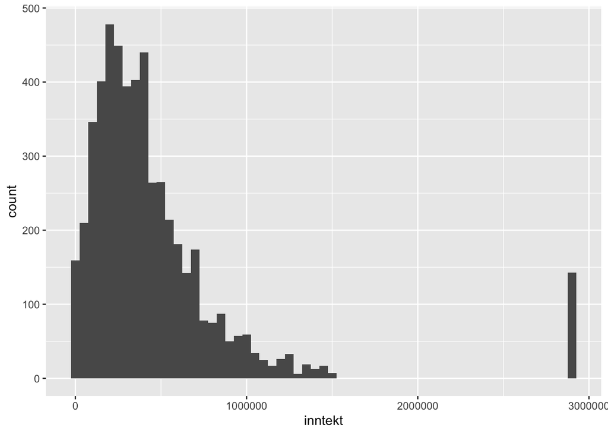

```r
# Nå filtrerer vi ut de observasjonene med inntekt høyere enn 0. Vi ser da under "Environment" at vi sitter igjen med 6863 observasjoner i datasettet "hoyde_max_inntekt".

hoyde_min_inntekt <- hoyde %>%
  filter(inntekt > 0)

# For illustrajonshensikter, kan vi også se hvordan dette histogrammet har endret seg i forhold til det forrige.

ggplot(data = hoyde_min_inntekt,
       aes(x = inntekt)) +
  geom_histogram(binwidth = 50000)
```

```r
(lm(inntekt ~ height_cm, data = hoyde_min_inntekt)) %>%
  summary()
```

```
##
## Call:
## lm(formula = inntekt ~ height_cm, data = hoyde_min_inntekt)
##
## Residuals:
##     Min      1Q  Median      3Q     Max
## -714128 -253106 -103101   95637 2634963
##
## Coefficients:
##               Estimate Std. Error t value            Pr(>|t|)
## (Intercept) -1435793.6   110687.8  -12.97 <0.0000000000000002 ***
## height_cm      11122.9      646.2   17.21 <0.0000000000000002 ***
## ---
## Signif. codes:  0 '***' 0.001 '**' 0.01 '*' 0.05 '.' 0.1 ' ' 1
##
## Residual standard error: 483000 on 5264 degrees of freedom
## Multiple R-squared:  0.05328,    Adjusted R-squared:  0.0531
## F-statistic: 296.3 on 1 and 5264 DF,  p-value: < 0.00000000000000022
```

Ovenfor er helt OK, men jeg synes altså det er mer hensiktsmessig å gjøre det på følgende måte:

```r
mod0 <- 'inntekt ~ height_cm'
lm0 <- hoyde %>%
  filter(inntekt > 0) %>%
  lm(mod0, data = .)
summary(lm0)
```

```
##
## Call:
## lm(formula = mod0, data = .)
##
## Residuals:
##     Min      1Q  Median      3Q     Max
## -714128 -253106 -103101   95637 2634963
##
## Coefficients:
##               Estimate Std. Error t value            Pr(>|t|)
## (Intercept) -1435793.6   110687.8  -12.97 <0.0000000000000002 ***
## height_cm      11122.9      646.2   17.21 <0.0000000000000002 ***
## ---
## Signif. codes:  0 '***' 0.001 '**' 0.01 '*' 0.05 '.' 0.1 ' ' 1
##
## Residual standard error: 483000 on 5264 degrees of freedom
## Multiple R-squared:  0.05328,    Adjusted R-squared:  0.0531
## F-statistic: 296.3 on 1 and 5264 DF,  p-value: < 0.00000000000000022
```

Her ser vi at en økning i høyden på 1 cm, gir 11122.9 kr mer i årlig inntekt.

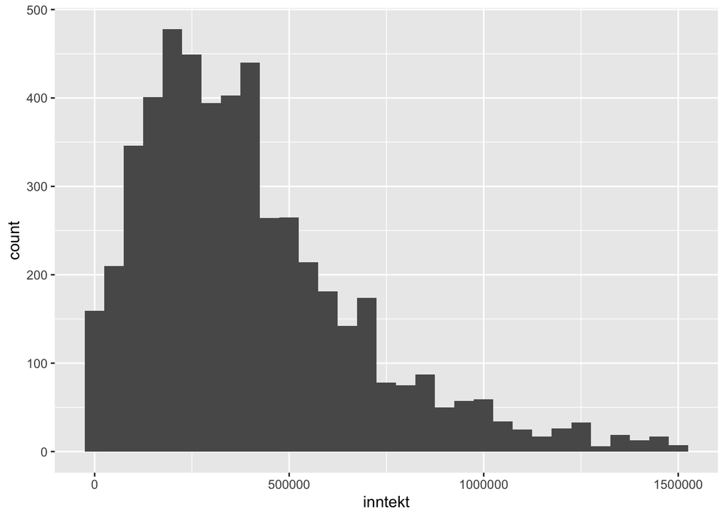

```r
# Her fjernes både 0 inntekt og topp 2% i samme modell istedenfor hver for seg som tidligere. Hensikten er ållustrere forskjellen mellom disse modellene.
# HVORFOR GÅ VEIEN OM NYTT DATASETT?
hoyde %>%
  filter(inntekt < 1600000) %>%
  filter(inntekt > 0) %>%
  # Fremstiller dette i ggplot for å illustrere forskjellen mellom modellene ovenfor grafisk.
  ggplot(aes(x = inntekt)) +
  geom_histogram(binwidth = 50000)
```

```r
# (lm(inntekt ~ height_cm, data = hoyde_min_og_max_inntekt)) %>%
#   summary()
```

```r
#Igjen synes jeg følgende er enklere

lm1 <- hoyde %>%
  filter(inntekt > 0 & inntekt < 3000000) %>%
  lm(mod0, data = .)
summary(lm1)
```

```
##
## Call:
## lm(formula = mod0, data = .)
##
## Residuals:
##     Min      1Q  Median      3Q     Max
## -714128 -253106 -103101   95637 2634963
##
## Coefficients:
##               Estimate Std. Error t value            Pr(>|t|)
## (Intercept) -1435793.6   110687.8  -12.97 <0.0000000000000002 ***
## height_cm      11122.9      646.2   17.21 <0.0000000000000002 ***
## ---
## Signif. codes:  0 '***' 0.001 '**' 0.01 '*' 0.05 '.' 0.1 ' ' 1
##
## Residual standard error: 483000 on 5264 degrees of freedom
## Multiple R-squared:  0.05328,    Adjusted R-squared:  0.0531
## F-statistic: 296.3 on 1 and 5264 DF,  p-value: < 0.00000000000000022
```

#### Forklaring til utliggere i plots

Som vi ser ut fra grafen er det en stor ujevnhet. I datasettet har den største andelen av observasjonene under ca 700 000 kroner, og minoriteten har over 700 000 kroner. 143 observasjoner har rett i underkant av 3 millioner kroner. Dette er det den høyre utliggeren i datasettet.

Vi har også med observasjoner *uten* lønn. Dette er den venstre utliggeren. Det er ca. 2000 observasjoner uten lønn.

Disse utliggerne *kan* påvirke resultatet av analysen. Disse to gruppene av ekstreme observasjonene *kan* resultere i at **(vi har jo ikke ennå vist at det gjør det)** sammenhengen mellom høyde og snitt- og medianlønn blir feilaktig fremstilt. Vi får dermed feil informasjon ut av dataene vi analyserer. Vi får tilfeller der en lav person ansees som arbeidsledig eller at en høy person har langt høyere inntekt, slik som analysen fra National Longitudinal Study kom frem til.

# Mutate: Nye Variabler

*tommer* er 2.54cm

*pund* er 450g, eller 0.45kg

Helt datasett, nye variabler, BMI og gift - ikke gift:

```r
hoyde <- hoyde %>%
  mutate(
    height_cm = 2.54 * height,
    weight_kg = weight * 0.45,
    bmi = (weight / (height_cm / 100)^2),
    married = factor(
      case_when(
      # note, summary showed no NA for marital
        marital =='married'~ TRUE,
        # all other categories FALSE
        TRUE ~ FALSE)
  )
)
```

Oppsummerer resultatet via *summary()*

```r
summary(hoyde)
```

```
##      income             height         weight           age
##  Min.   :     0.0   Min.   :52.0   Min.   : 76.0   Min.   :47.00
##  1st Qu.:   165.5   1st Qu.:64.0   1st Qu.:157.0   1st Qu.:49.00
##  Median : 29589.5   Median :67.0   Median :184.0   Median :51.00
##  Mean   : 41203.9   Mean   :67.1   Mean   :188.3   Mean   :51.33
##  3rd Qu.: 55000.0   3rd Qu.:70.0   3rd Qu.:212.0   3rd Qu.:53.00
##  Max.   :343830.0   Max.   :84.0   Max.   :524.0   Max.   :56.00
##                                    NA's   :95
##       marital         sex         education          afqt
##  single   :1124   male  :3402   Min.   : 1.00   Min.   :  0.00
##  married  :3806   female:3604   1st Qu.:12.00   1st Qu.: 15.12
##  separated: 366                 Median :12.00   Median : 36.76
##  divorced :1549                 Mean   :13.22   Mean   : 41.21
##  widowed  : 161                 3rd Qu.:15.00   3rd Qu.: 65.24
##                                 Max.   :20.00   Max.   :100.00
##                                 NA's   :10      NA's   :262
##     inntekt          height_cm       weight_kg           bmi
##  Min.   :      0   Min.   :132.1   Min.   : 34.20   Min.   : 28.38
##  1st Qu.:   1407   1st Qu.:162.6   1st Qu.: 70.65   1st Qu.: 55.31
##  Median : 251511   Median :170.2   Median : 82.80   Median : 62.44
##  Mean   : 350234   Mean   :170.4   Mean   : 84.74   Mean   : 64.61
##  3rd Qu.: 467500   3rd Qu.:177.8   3rd Qu.: 95.40   3rd Qu.: 71.17
##  Max.   :2922555   Max.   :213.4   Max.   :235.80   Max.   :165.32
##                                    NA's   :95       NA's   :95
##   married
##  FALSE:3200
##  TRUE :3806
##
##
##
##
##
```

Filtrert datasett, nye variabler, BMI og gift - ikke gift:

```r
hoyde_min_og_max_inntekt <- hoyde %>%
  filter(inntekt > 0 & inntekt < 3000000)
#####
hoyde_filtrert <- hoyde_min_og_max_inntekt %>%
  mutate(
    height_cm = 2.54 * height,
    weight_kg = weight * 0.45,
    bmi = (weight / (height_cm / 100)^2),
    married = factor(
      case_when(
      # note, summary showed no NA for marital
        marital =='married'~ TRUE,
        # all other categories FALSE
        TRUE ~ FALSE)
    )
  )
```

Oppsummerer resultatet via *summary()*

```r
summary(hoyde_filtrert)
```

```
##      income           height          weight           age
##  Min.   :    45   Min.   :52.00   Min.   : 78.0   Min.   :47.00
##  1st Qu.: 23425   1st Qu.:64.00   1st Qu.:160.0   1st Qu.:49.00
##  Median : 40000   Median :67.00   Median :185.0   Median :51.00
##  Mean   : 54819   Mean   :67.31   Mean   :188.6   Mean   :51.28
##  3rd Qu.: 65000   3rd Qu.:70.00   3rd Qu.:212.0   3rd Qu.:53.00
##  Max.   :343830   Max.   :81.00   Max.   :480.0   Max.   :56.00
##                                   NA's   :69
##       marital         sex         education          afqt
##  single   : 710   male  :2657   Min.   : 1.00   Min.   :  0.00
##  married  :3101   female:2609   1st Qu.:12.00   1st Qu.: 20.08
##  separated: 233                 Median :13.00   Median : 42.85
##  divorced :1115                 Mean   :13.57   Mean   : 45.35
##  widowed  : 107                 3rd Qu.:16.00   3rd Qu.: 69.65
##                                 Max.   :20.00   Max.   :100.00
##                                 NA's   :2       NA's   :184
##     inntekt            height_cm       weight_kg           bmi
##  Min.   :    382.5   Min.   :132.1   Min.   : 35.10   Min.   : 28.38
##  1st Qu.: 199112.5   1st Qu.:162.6   1st Qu.: 72.00   1st Qu.: 55.35
##  Median : 340000.0   Median :170.2   Median : 83.25   Median : 62.32
##  Mean   : 465958.2   Mean   :171.0   Mean   : 84.86   Mean   : 64.27
##  3rd Qu.: 552500.0   3rd Qu.:177.8   3rd Qu.: 95.40   3rd Qu.: 70.69
##  Max.   :2922555.0   Max.   :205.7   Max.   :216.00   Max.   :147.59
##                                      NA's   :69       NA's   :69
##   married
##  FALSE:2165
##  TRUE :3101
##
##
##
##
##
```

EN BEDRE STRATEGI VIL VÆRE Å DEFINERE DE NYE VARIABLENE I hoyde OG SÅ BARE FILTRERE hoyde I EN PIPE FØR EVENTUELLE lm eller ggplot KOMMANDOER. GIR MER OVERSIKTRLIG KODE SOM OGSÅ ER LETTERE Å ENDRE PÅ F.EKS

```r
hoyde <- hoyde %>%
  mutate(
    height_cm = 2.54 * height,
    weight_kg = weight * 0.45,
    bmi = (weight / (height_cm / 100)^2),
    married = factor(
      case_when(
      # note, summary showed no NA for marital
        marital =='married'~ TRUE,
        # all other categories FALSE
        TRUE ~ FALSE)
    )
  )
```

```r
mod_ag <- 'inntekt ~ sex*(education + afqt + married)'
lm_ag_red <- hoyde %>%
  filter(inntekt > 0 & inntekt < 3000000) %>%
  lm(mod_ag, data = .)
```

Samme modell med hele datasettet

```r
mod_ag <- 'inntekt ~ sex*(education + afqt + married)'
lm_ag <- hoyde %>%
  lm(mod_ag, data = .)
```

```r
huxreg(
  list("M_1" = lm_ag, "M_1_red" = lm_ag_red),
  error_format = "[{statistic}]")
```

|  | M_1 | M_1_red |
| --- | --- | --- |
| (Intercept) | -725855.536 *** | -693036.823 *** |
|  | [-17.910] | [-14.240] |
| sexfemale | 447907.945 *** | 475715.331 *** |
|  | [8.072] | [6.933] |
| education | 67949.905 *** | 73678.143 *** |
|  | [18.978] | [17.582] |
| afqt | 4613.079 *** | 4321.108 *** |
|  | [14.928] | [11.859] |
| marriedTRUE | 187669.370 *** | 148858.330 *** |
|  | [12.689] | [8.300] |
| sexfemale:education | -34052.724 *** | -38565.284 *** |
|  | [-7.139] | [-6.751] |
| sexfemale:afqt | -2632.390 *** | -2408.763 *** |
|  | [-6.115] | [-4.656] |
| sexfemale:marriedTRUE | -192171.295 *** | -152016.276 *** |
|  | [-9.384] | [-6.067] |
| N | 6735 | 5080 |
| R2 | 0.293 | 0.277 |
| logLik | -96505.739 | -73072.901 |
| AIC | 193029.479 | 146163.801 |
| *** p < 0.001; ** p < 0.01; * p < 0.05. |  |  |

# HuxReg

Setter opp for å sette opp en HuxTable på datasettene med nye variabler.

*lm_hoyde* er fulle datasettet, men med nye variabler.

```r
lm_hoyde <- (lm(
  inntekt ~ height_cm + weight_kg + marital + bmi,
                data = hoyde))
lm_hoyde_filtrert <- (lm(
  inntekt ~ height_cm + weight_kg + marital + bmi,
                         data = hoyde_filtrert))
```

Setter opp til liste med avvik innenfor statistikk. Gir navn til tabellene våres for bedre oversikt.

```r
huxreg(
  list("hoyde"=lm_hoyde, "hoyde_filtrert"=lm_hoyde_filtrert),
  error_format = "[{statistic}]")
```

|  | hoyde | hoyde_filtrert |
| --- | --- | --- |
| (Intercept) | -2321309.587 *** | -2758058.879 *** |
|  | [-5.427] | [-5.009] |
| height_cm | 15611.913 *** | 19061.332 *** |
|  | [6.176] | [5.885] |
| weight_kg | -6129.694 * | -8580.496 ** |
|  | [-2.483] | [-2.705] |
| maritalmarried | 207941.582 *** | 168873.187 *** |
|  | [13.291] | [8.412] |
| maritalseparated | -32637.320 | -64984.272 |
|  | [-1.179] | [-1.780] |
| maritaldivorced | 70126.781 *** | 53977.336 * |
|  | [3.882] | [2.327] |
| maritalwidowed | 33568.334 | 9420.220 |
|  | [0.863] | [0.188] |
| bmi | 6226.873 | 9095.815 * |
|  | [1.958] | [2.202] |
| N | 6911 | 5197 |
| R2 | 0.088 | 0.081 |
| logLik | -99857.326 | -75339.363 |
| AIC | 199732.653 | 150696.727 |
| *** p < 0.001; ** p < 0.01; * p < 0.05. |  |  |

De mest akutelle faktorene for studien denne innleveringen baserer seg på er:

*height_cm*, *weight_kg*, *N*, *R^2*

# Test av robusthet

Robushets refereres til styrken av den anvendte statistiske modellen, og kan eksempelvis være å utføre en t-test. Dette type test er en hypotesetest og brukes for å teste hvorvidt gjennomsnitssverdien i et normalfordelt datasatt er signifikant forskjellig fra en nullhypotese.

Vi må først definere $H_0$ og $H_1$, og deretter tar vi en titt på t-verdiene til de ulike variablene og ser om de er signifikante.

$H_0: Liten endring i t-verdi og signifikansnivå for høyde$ $H_1: Høyde har mindre betydning enn anntat, større avvik i t-verdier$

## Modellene

Modeller uten observasjoner med 0 i inntekt:

```r
modell_1 <- "inntekt ~ height_cm"
lm1 <- lm(modell_1, data = hoyde_min_inntekt)
summary(lm1)
```

```
##
## Call:
## lm(formula = modell_1, data = hoyde_min_inntekt)
##
## Residuals:
##     Min      1Q  Median      3Q     Max
## -714128 -253106 -103101   95637 2634963
##
## Coefficients:
##               Estimate Std. Error t value            Pr(>|t|)
## (Intercept) -1435793.6   110687.8  -12.97 <0.0000000000000002 ***
## height_cm      11122.9      646.2   17.21 <0.0000000000000002 ***
## ---
## Signif. codes:  0 '***' 0.001 '**' 0.01 '*' 0.05 '.' 0.1 ' ' 1
##
## Residual standard error: 483000 on 5264 degrees of freedom
## Multiple R-squared:  0.05328,    Adjusted R-squared:  0.0531
## F-statistic: 296.3 on 1 and 5264 DF,  p-value: < 0.00000000000000022
```

```r
modell_2 <- "inntekt ~ height_cm + weight + marital"
lm2 <- lm(modell_2, data = hoyde_min_inntekt)
summary (lm2)
```

```
##
## Call:
## lm(formula = modell_2, data = hoyde_min_inntekt)
##
## Residuals:
##     Min      1Q  Median      3Q     Max
## -746084 -252292  -98264  100382 2585620
##
## Coefficients:
##                    Estimate Std. Error t value             Pr(>|t|)
## (Intercept)      -1572607.8   116340.3 -13.517 < 0.0000000000000002 ***
## height_cm           12121.0      748.7  16.189 < 0.0000000000000002 ***
## weight               -741.9      179.9  -4.125            0.0000377 ***
## maritalmarried     166514.8    20054.3   8.303 < 0.0000000000000002 ***
## maritalseparated   -66105.1    36509.9  -1.811               0.0703 .
## maritaldivorced     52220.2    23190.2   2.252               0.0244 *
## maritalwidowed       7776.9    50210.9   0.155               0.8769
## ---
## Signif. codes:  0 '***' 0.001 '**' 0.01 '*' 0.05 '.' 0.1 ' ' 1
##
## Residual standard error: 478700 on 5190 degrees of freedom
##   (69 observations deleted due to missingness)
## Multiple R-squared:  0.07994,    Adjusted R-squared:  0.07887
## F-statistic: 75.15 on 6 and 5190 DF,  p-value: < 0.00000000000000022
```

```r
modell_3 <- "inntekt ~ sex*height_cm + weight + marital"
lm3 <- lm(modell_3, data = hoyde_min_inntekt)
summary(lm3)
```

```
##
## Call:
## lm(formula = modell_3, data = hoyde_min_inntekt)
##
## Residuals:
##     Min      1Q  Median      3Q     Max
## -748598 -252959  -97185  103409 2657787
##
## Coefficients:
##                       Estimate Std. Error t value             Pr(>|t|)
## (Intercept)         -1087464.6   226208.6  -4.807    0.000001572603235 ***
## sexfemale             750581.1   319561.7   2.349              0.01887 *
## height_cm               9685.6     1312.6   7.379    0.000000000000185 ***
## weight                  -829.8      179.3  -4.628    0.000003783773448 ***
## maritalmarried        165425.3    19946.9   8.293 < 0.0000000000000002 ***
## maritalseparated      -58590.2    36319.5  -1.613              0.10676
## maritaldivorced        54144.2    23073.3   2.347              0.01898 *
## maritalwidowed         31950.8    50034.9   0.639              0.52313
## sexfemale:height_cm    -5248.1     1875.1  -2.799              0.00515 **
## ---
## Signif. codes:  0 '***' 0.001 '**' 0.01 '*' 0.05 '.' 0.1 ' ' 1
##
## Residual standard error: 476000 on 5188 degrees of freedom
##   (69 observations deleted due to missingness)
## Multiple R-squared:  0.09087,    Adjusted R-squared:  0.08946
## F-statistic: 64.82 on 8 and 5188 DF,  p-value: < 0.00000000000000022
```

Test av koeffisienter:

```r
linearHypothesis(lm3, c("sexfemale = 0", "sexfemale:height_cm = 0"))
```

| Res.Df | RSS | Df | Sum of Sq | F | Pr(>F) |
| --- | --- | --- | --- | --- | --- |
| 5.19e+03 | 1.19e+15 |  |  |  |  |
| 5.19e+03 | 1.18e+15 | 2 | 1.41e+13 | 31.2 | 3.46e-14 |

Modeller uten observasjonene med topp 2% i inntekt:

```r
modell_4 <- "inntekt ~ height_cm"
lm4 <- lm(modell_4, data = hoyde_max_inntekt)
summary(lm4)
```

```
##
## Call:
## lm(formula = modell_4, data = hoyde_max_inntekt)
##
## Residuals:
##     Min      1Q  Median      3Q     Max
## -547811 -236923  -54031  158327 1265382
##
## Coefficients:
##              Estimate Std. Error t value            Pr(>|t|)
## (Intercept) -695742.7    58424.7  -11.91 <0.0000000000000002 ***
## height_cm      5828.4      342.5   17.02 <0.0000000000000002 ***
## ---
## Signif. codes:  0 '***' 0.001 '**' 0.01 '*' 0.05 '.' 0.1 ' ' 1
##
## Residual standard error: 293300 on 6861 degrees of freedom
## Multiple R-squared:  0.0405, Adjusted R-squared:  0.04036
## F-statistic: 289.6 on 1 and 6861 DF,  p-value: < 0.00000000000000022
```

```r
modell_5 <- "inntekt ~ height_cm + weight + marital"
lm5 <- lm(modell_5, data = hoyde_max_inntekt)
summary(lm5)
```

```
##
## Call:
## lm(formula = modell_5, data = hoyde_max_inntekt)
##
## Residuals:
##     Min      1Q  Median      3Q     Max
## -552630 -213609  -54102  149212 1282160
##
## Coefficients:
##                    Estimate Std. Error t value             Pr(>|t|)
## (Intercept)      -805106.56   59964.37 -13.426 < 0.0000000000000002 ***
## height_cm           6188.47     382.24  16.190 < 0.0000000000000002 ***
## weight              -268.85      88.48  -3.039              0.00239 **
## maritalmarried    155353.49    9876.94  15.729 < 0.0000000000000002 ***
## maritalseparated  -12818.20   17385.95  -0.737              0.46098
## maritaldivorced    68638.64   11379.36   6.032        0.00000000171 ***
## maritalwidowed     19719.18   24496.96   0.805              0.42087
## ---
## Signif. codes:  0 '***' 0.001 '**' 0.01 '*' 0.05 '.' 0.1 ' ' 1
##
## Residual standard error: 286200 on 6761 degrees of freedom
##   (95 observations deleted due to missingness)
## Multiple R-squared:  0.09079,    Adjusted R-squared:  0.08999
## F-statistic: 112.5 on 6 and 6761 DF,  p-value: < 0.00000000000000022
```

```r
modell_6 <- "inntekt ~ sex*height_cm + weight + marital"
lm6 <- lm(modell_6, data = hoyde_max_inntekt)
summary(lm6)
```

```
##
## Call:
## lm(formula = modell_6, data = hoyde_max_inntekt)
##
## Residuals:
##     Min      1Q  Median      3Q     Max
## -534187 -212964  -53532  149687 1276649
##
## Coefficients:
##                       Estimate Std. Error t value             Pr(>|t|)
## (Intercept)         -542258.82  118177.26  -4.589      0.0000045445601 ***
## sexfemale            192793.51  163358.92   1.180             0.237969
## height_cm              4812.42     686.42   7.011      0.0000000000026 ***
## weight                 -291.14      88.43  -3.292             0.000998 ***
## maritalmarried       158245.57    9870.39  16.032 < 0.0000000000000002 ***
## maritalseparated      -8214.16   17360.89  -0.473             0.636127
## maritaldivorced       71219.50   11360.29   6.269      0.0000000003854 ***
## maritalwidowed        31331.27   24494.07   1.279             0.200893
## sexfemale:height_cm   -1498.89     958.11  -1.564             0.117763
## ---
## Signif. codes:  0 '***' 0.001 '**' 0.01 '*' 0.05 '.' 0.1 ' ' 1
##
## Residual standard error: 285400 on 6759 degrees of freedom
##   (95 observations deleted due to missingness)
## Multiple R-squared:  0.0964, Adjusted R-squared:  0.09533
## F-statistic: 90.13 on 8 and 6759 DF,  p-value: < 0.00000000000000022
```

Test av koeffisienter:

```r
linearHypothesis(lm6, c("sexfemale = 0", "sexfemale:height_cm = 0"))
```

| Res.Df | RSS | Df | Sum of Sq | F | Pr(>F) |
| --- | --- | --- | --- | --- | --- |
| 6.76e+03 | 5.54e+14 |  |  |  |  |
| 6.76e+03 | 5.5e+14 | 2 | 3.41e+12 | 21 | 8.46e-10 |

### Kommentarer til modellene ovenfor.

Modell 3 tar med flere variabler og vi ser da at t-verdien til høyde faller til 7.379, mens den fortsatt er signifikant på 0.001 nivå, som virker lovendes. Men vi ser også nå at kjønn har en t-verdi på 2.349 og signifikansnivå på 0.05, og om vedkommende er gift har t-verdi på 8.293 med 0.001 signifikans nivå. Vi ser her at høyde har fått en betraktelig mindre betydning når vi har lagt til flere variabler, der flere av de variablene har en stor betydning i iht. t-verdiene og signifikansnivåene.

For modellene uten topp 2% inntekt ser vi akkurat samme tendens. Flere desto flere variabler, desto mindre betydning har høyden.

Vi ser også en annen tendens, som viser seg ved at idet øyeblikket vi legger til kjønn som en variabel, stuper t-verdien til høyde med 10. Vi kan dermed si med ganske stor sannsynlighet at kjønn har en enorm stor påvirkning på inntekten til personener.

## Modell uten både 0 og topp 2%

Men hva skjer om vi lager en modell der vi tar bort både arbeidsledige og topp 2% inntektsgruppen?

```r
modell_7 <- "inntekt ~ height_cm"
lm7 <- lm(modell_7, data = hoyde_filtrert)
summary(lm7)
```

```
##
## Call:
## lm(formula = modell_7, data = hoyde_filtrert)
##
## Residuals:
##     Min      1Q  Median      3Q     Max
## -714128 -253106 -103101   95637 2634963
##
## Coefficients:
##               Estimate Std. Error t value            Pr(>|t|)
## (Intercept) -1435793.6   110687.8  -12.97 <0.0000000000000002 ***
## height_cm      11122.9      646.2   17.21 <0.0000000000000002 ***
## ---
## Signif. codes:  0 '***' 0.001 '**' 0.01 '*' 0.05 '.' 0.1 ' ' 1
##
## Residual standard error: 483000 on 5264 degrees of freedom
## Multiple R-squared:  0.05328,    Adjusted R-squared:  0.0531
## F-statistic: 296.3 on 1 and 5264 DF,  p-value: < 0.00000000000000022
```

```r
modell_8 <- "inntekt ~ sex*height_cm + weight_kg + marital"
lm8 <- lm(modell_8, data = hoyde_filtrert)
summary(lm8)
```

```
##
## Call:
## lm(formula = modell_8, data = hoyde_filtrert)
##
## Residuals:
##     Min      1Q  Median      3Q     Max
## -748598 -252959  -97185  103409 2657787
##
## Coefficients:
##                       Estimate Std. Error t value             Pr(>|t|)
## (Intercept)         -1087464.6   226208.6  -4.807    0.000001572603235 ***
## sexfemale             750581.1   319561.7   2.349              0.01887 *
## height_cm               9685.6     1312.6   7.379    0.000000000000185 ***
## weight_kg              -1844.0      398.5  -4.628    0.000003783773448 ***
## maritalmarried        165425.3    19946.9   8.293 < 0.0000000000000002 ***
## maritalseparated      -58590.2    36319.5  -1.613              0.10676
## maritaldivorced        54144.2    23073.3   2.347              0.01898 *
## maritalwidowed         31950.8    50034.9   0.639              0.52313
## sexfemale:height_cm    -5248.1     1875.1  -2.799              0.00515 **
## ---
## Signif. codes:  0 '***' 0.001 '**' 0.01 '*' 0.05 '.' 0.1 ' ' 1
##
## Residual standard error: 476000 on 5188 degrees of freedom
##   (69 observations deleted due to missingness)
## Multiple R-squared:  0.09087,    Adjusted R-squared:  0.08946
## F-statistic: 64.82 on 8 and 5188 DF,  p-value: < 0.00000000000000022
```

```r
modell_9 <- "inntekt ~ sex*(height_cm + weight_kg + marital + bmi + education + age)"
lm9 <- lm(modell_9, data = hoyde_filtrert)
summary(lm9)
```

```
##
## Call:
## lm(formula = modell_9, data = hoyde_filtrert)
##
## Residuals:
##      Min       1Q   Median       3Q      Max
## -1159406  -207853   -60026   102655  2858592
##
## Coefficients:
##                            Estimate Std. Error t value             Pr(>|t|)
## (Intercept)                -3091801    1152742  -2.682             0.007339 **
## sexfemale                   1931974    1506243   1.283             0.199674
## height_cm                     15003       6352   2.362             0.018215 *
## weight_kg                    -12369       6040  -2.048             0.040642 *
## maritalmarried               224202      24774   9.050 < 0.0000000000000002 ***
## maritalseparated              -4390      49120  -0.089             0.928792
## maritaldivorced               99522      29685   3.353             0.000806 ***
## maritalwidowed               100588     104216   0.965             0.334496
## bmi                           15818       8744   1.809             0.070524 .
## education                     99677       3335  29.890 < 0.0000000000000002 ***
## age                           -7261       3781  -1.920             0.054851 .
## sexfemale:height_cm           -9206       8613  -1.069             0.285220
## sexfemale:weight_kg            7423       8474   0.876             0.381101
## sexfemale:maritalmarried    -216660      36520  -5.933        0.00000000317 ***
## sexfemale:maritalseparated   -55543      66449  -0.836             0.403261
## sexfemale:maritaldivorced    -90746      41979  -2.162             0.030687 *
## sexfemale:maritalwidowed    -107702     116552  -0.924             0.355494
## sexfemale:bmi                -11170      11279  -0.990             0.322070
## sexfemale:education          -55733       4762 -11.704 < 0.0000000000000002 ***
## sexfemale:age                  7950       5374   1.479             0.139068
## ---
## Signif. codes:  0 '***' 0.001 '**' 0.01 '*' 0.05 '.' 0.1 ' ' 1
##
## Residual standard error: 430800 on 5175 degrees of freedom
##   (71 observations deleted due to missingness)
## Multiple R-squared:  0.257,  Adjusted R-squared:  0.2543
## F-statistic: 94.22 on 19 and 5175 DF,  p-value: < 0.00000000000000022
```

Test av koeffisienter:

```r
linearHypothesis(lm9, c("sexfemale = 0", "sexfemale:height_cm = 0"))
```

| Res.Df | RSS | Df | Sum of Sq | F | Pr(>F) |
| --- | --- | --- | --- | --- | --- |
| 5.18e+03 | 9.61e+14 |  |  |  |  |
| 5.18e+03 | 9.6e+14 | 2 | 4.69e+11 | 1.26 | 0.283 |

### Kommentar til modell 7, 8 og 9

#### Resultat

Høyde alene er ikke de-facto grunnlag for høyere lønn, det er andre faktorer med som påvirker.